# Iteration

```r
library(tidyverse)
```

```r
library(repurrrsive)
library(broom)
names(sw_people) <- sw_people %>% map_chr("name")

# Toy data
set.seed(1000)
exams <- list(
  student1 = round(runif(10, 50, 100)),
  student2 = round(runif(10, 50, 100)),
  student3 = round(runif(10, 50, 100)),
  student4 = round(runif(10, 50, 100)),
  student5 = round(runif(10, 50, 100))
)

extra_credit <- list(0, 0, 10, 10, 15)

names(who) <- str_replace(names(who), "newrel", "new_rel")
tb <-
  who %>%
  gather("codes", "n", 5:60) %>%
  separate(codes, c("new", "type", "sexage"), sep = "_") %>%
  select(-new, -iso2, -iso3) %>%
  separate(sexage, c("sex", "age"), sep = 1) %>%
  drop_na(n)
```

# Mapping

## Your Turn 1

Run the code in the chunk. What does it do?

```r
#View(exams)
exams %>% map(mean)
```

```
## $student1
## [1] 71.4
##
## $student2
## [1] 74.6
##
## $student3
## [1] 70.2
##
## $student4
## [1] 75.1
##
## $student5
## [1] 79.1
```

> Creates a list with students of their mean scores

## Your Turn 2

Complete the code to apply the test below to every element of the list. Return the results as a vector.

`length(<input> == 10)`

```r
exams %>% map(~length(.)==10)
```

```
## $student1
## [1] TRUE
##
## $student2
## [1] TRUE
##
## $student3
## [1] TRUE
##
## $student4
## [1] TRUE
##
## $student5
## [1] TRUE
```

## Your Turn 3

Recompute the grades by dropping the lowest score and then taking the mean of the rest, i.e. Return the results as a *double* vector.

`(sum(<input>) - min(<input>)) / 9`

```r
exams %>%
  map_dbl(~(sum(.) - min(.)) / 9)
```

```
## student1 student2 student3 student4 student5
## 73.44444 76.88889 72.00000 77.77778 81.77778
```

## Your Turn 4

Compute a final grade for each student, where the final grade is the average test score plus any `extra_credit` assigned to the student. Return the results as a double (i.e. numeric) vector.

`mean(<exams>) + <extra_credit>`

```r
exams %>%
  map2_dbl(extra_credit, ~mean(.x) + .y)
```

```
## student1 student2 student3 student4 student5
##     71.4     74.6     80.2     85.1     94.1
```

# Putting it all together

Predict TB cases in 2020 for Afghanistan

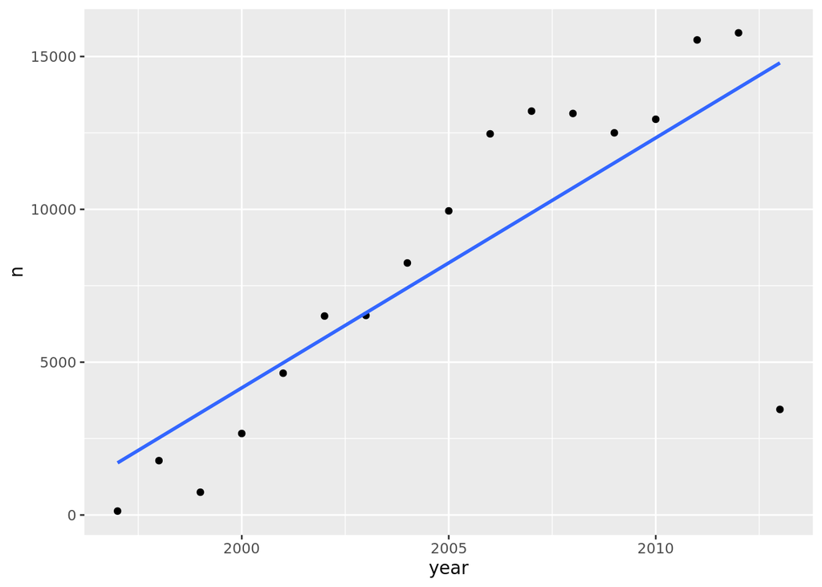

```r
tb %>%
  filter(country == "Afghanistan") %>%
  group_by(year) %>%
  summarise(n = sum(n)) %>%
  ggplot(aes(x = year, y = n)) +
  geom_point() +
  geom_smooth(method = "lm", se = FALSE)
```

```r
tb %>%
  filter(country == "Afghanistan") %>%
  group_by(year) %>%
  summarise(n = sum(n)) %>%
  lm(n ~ year, data = .) %>%
  predict(newdata = tibble(year = 2020)) %>%
  round()
```

```
##     1
## 20517
```

Predict TB cases in 2020 for each country

```r
tb_predictions <-
  tb %>%
  group_by(country, year) %>%
  summarise(n = sum(n)) %>%
  nest() %>%
  mutate(model = map(data, ~lm(n ~ year, data = .))) %>%
  mutate(pred = map_dbl(model, predict, tibble(year = 2020))) %>%
  mutate(pred = round(pred))
```

Things that we can now do:

- Which countries will have the most cases?
- What does the data look like for India?
- How do the Korea’s compare?

```r
tb_predictions %>%
  select(country, pred) %>%
  arrange(desc(pred))
```

```
## # A tibble: 219 × 2
## # Groups:   country [219]
##    country                                  pred
##    <chr>                                   <dbl>
##  1 India                                 1237653
##  2 China                                 1183989
##  3 South Africa                           585015
##  4 Indonesia                              495358
##  5 Bangladesh                             224973
##  6 Russian Federation                     173435
##  7 Pakistan                               167735
##  8 Philippines                            157095
##  9 Democratic People's Republic of Korea  130053
## 10 Kenya                                  114537
## # … with 209 more rows
```

```r
tb_predictions %>%
  filter(country=="India") %>%
  unnest(data)
```

```
## # A tibble: 18 × 5
## # Groups:   country [1]
##    country  year       n model     pred
##    <chr>   <int>   <int> <list>   <dbl>
##  1 India    1995    1985 <lm>   1237653
##  2 India    1996    6254 <lm>   1237653
##  3 India    1997    7708 <lm>   1237653
##  4 India    1998   12421 <lm>   1237653
##  5 India    1999   52900 <lm>   1237653
##  6 India    2000  193149 <lm>   1237653
##  7 India    2001  185277 <lm>   1237653
##  8 India    2002  351493 <lm>   1237653
##  9 India    2003  404884 <lm>   1237653
## 10 India    2004  479665 <lm>   1237653
## 11 India    2005  508557 <lm>   1237653
## 12 India    2006  553797 <lm>   1237653
## 13 India    2007 1198289 <lm>   1237653
## 14 India    2008  615492 <lm>   1237653
## 15 India    2009  624617 <lm>   1237653
## 16 India    2010  630164 <lm>   1237653
## 17 India    2011  642311 <lm>   1237653
## 18 India    2012  629589 <lm>   1237653
```

```r
tb_predictions %>%
  filter(str_detect(country,"Korea")) %>%
  select(country, pred)
```

```
## # A tibble: 2 × 2
## # Groups:   country [2]
##   country                                 pred
##   <chr>                                  <dbl>
## 1 Democratic People's Republic of Korea 130053
## 2 Republic of Korea                      56401
```

Take Aways

- Use `View()` to inspect lists
- Use `pluck()`, `[[ ]]`, or `$` to extract values from lists
- Use purrr’s `map()` functions to manipulate lists
- Lists can be a column in a data frame
- Tables are an organizational structure that you can manipulate.